# Day 4 - tidyverse and visualizations

## Making plots with ggplot2

We will primarily be working in ggplot2 as it has the greatest degree of customization for visualization and offers many additional features over the basic plotting in R.

```r
library(ggplot2)
library(tidyverse)
```

### Getting started with a ggplot

Most ggplot calls to create a figure take the following form (you can read more using `help(ggplot)`):

`ggplot(data = <DATA>, mapping = aes(<MAPPINGS>)) + <GEOM_FUNCTION>()`

We will practice using our mammalian sleep dataset. You can look up more info about this dataset using the `help` function and the dataset name, `msleep`.

```r
head(msleep)
```

```
## # A tibble: 6 x 11
##   name  genus vore  order conservation sleep_total sleep_rem sleep_cycle awake
##   <chr> <chr> <chr> <chr> <chr>              <dbl>     <dbl>       <dbl> <dbl>
## 1 Chee… Acin… carni Carn… lc                  12.1      NA        NA      11.9
## 2 Owl … Aotus omni  Prim… <NA>                17         1.8      NA       7
## 3 Moun… Aplo… herbi Rode… nt                  14.4       2.4      NA       9.6
## 4 Grea… Blar… omni  Sori… lc                  14.9       2.3       0.133   9.1
## 5 Cow   Bos   herbi Arti… domesticated         4         0.7       0.667  20
## 6 Thre… Brad… herbi Pilo… <NA>                14.4       2.2       0.767   9.6
## # … with 2 more variables: brainwt <dbl>, bodywt <dbl>
```

You will first use the `ggplot()` function and bind the plot to a specific data frame using the data argument.

`ggplot(data = msleep)`

You will next need to define a mapping (using the aesthetic or `aes` function), by selecting the variables to be plotted and specifying how to present them in the graph, e.g. as x/y positions or characteristics such as size, shape, color, etc.

`ggplot(data = msleep, aes(x = brainwt, y = sleep_rem))`

You can then add “geoms” or graphical representations of the data in the plot (points, lines, bars). `ggplot2` offers many different geoms including:

- `geom_point()` for scatter plots, dot plots, etc.
- `geom_boxplot()` for, well, boxplots!
- `geom_line()` for trend lines, time series, etc.

To add a geom to the plot use the `+` operator. To plot using two continuous variables, we will use `geom_point()` first. To save your work-in-progress, you can assign the plot to a variable.

First we establish our coordinate system.

```r
my.plot <- ggplot(data = msleep, aes(x = brainwt, y = sleep_rem))
```

We can now draw the plot as a scatterplot with points to represent each mammal’s measurements from the `msleep` dataset.

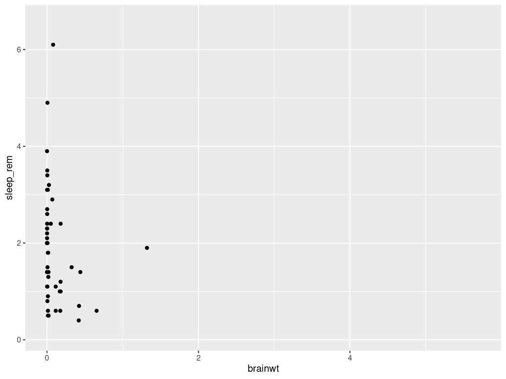

```r
my.plot + geom_point()
```

You might notice that all of the points are squished against the y-axis since many of the mammals in this dataset have low brain weights.

```r
summary(msleep$brainwt)
```

```
##    Min. 1st Qu.  Median    Mean 3rd Qu.    Max.    NA's
## 0.00014 0.00290 0.01240 0.28158 0.12550 5.71200      27
```

As you can see with the `summary` function, the minimum and median values are very low, but there are a few mammals with high `brainwt` as you can see by the much larger maximum value in this vector.

To make more useful plots, we can transform this value using log-scaling. While we will have to note that the new values do not exactly match the real-world measurements anymore, patterns we see (i.e. something that correlates with higher brain weights) will still hold true.

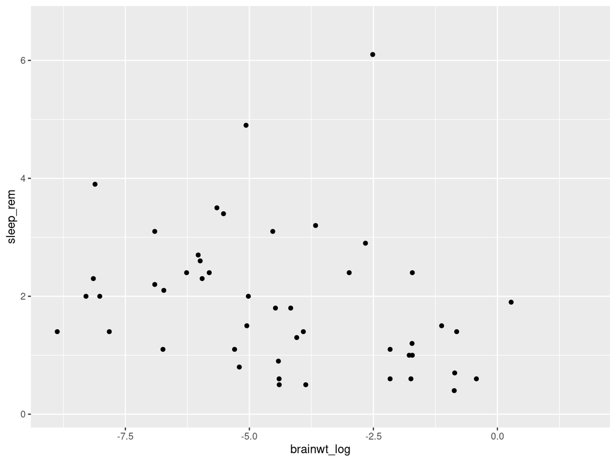

```r
msleep2 <- msleep %>% mutate(brainwt_log = log(brainwt))
ggplot(msleep2, aes(x = brainwt_log, y = sleep_rem)) + geom_point()
```

Here we use the `mutate` function to make a new variable called `brainwt_log` in our dataset (technically a new dataset copy that we have saved as `msleep2`). Plotting this variable as our x variable (i.e. independent variable), makes it easier to look for patterns.

### Changing plot aesthetics

We can modify the appearance of the plot in two ways: either uniformly changing the appearance or having the appearance vary depending on information present in our data.

Let’s explore how to modify our plots uniformly. We can change aspects of the points we plot such as transparency (“alpha”) and color by supplying them as arguments in the `geom_point` function.

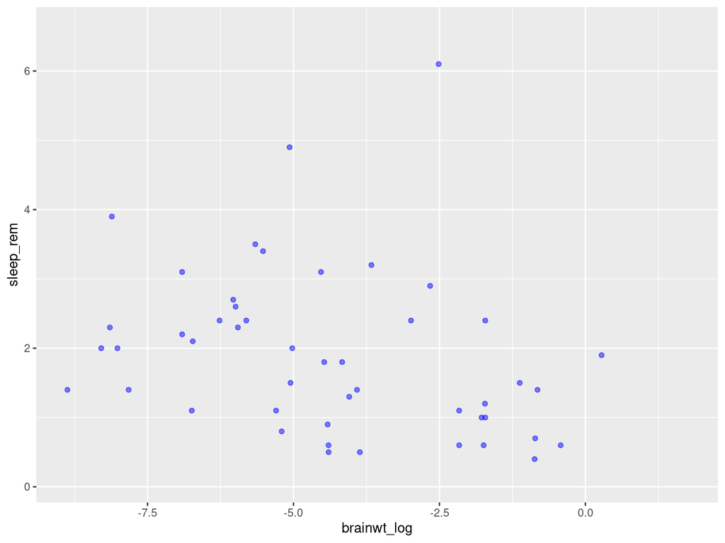

```r
ggplot(data = msleep2, aes(x = brainwt_log, y = sleep_rem)) +
    geom_point(alpha = 0.5, color = "blue")
```

Here we have made the plots semi-transparent and colored blue. You can try varying these values (e.g. change blue to a different color). You can also supply other arguments such as `shape` to use something other than a dot.

However, it is also possible to scale the color of the points by some variable present in the data. This approach means we can create a scatterplot that conveys more than just two variables’ worth of information (x-axis and y-axis) by having the color reflect a third variable.

To do this, we specify the `color` inside the aesthetic mapping `aes` within the initial `ggplot` function. Same as how we told R to use a specific column by name for `x` or `y` coordinates, we specify which column to use for `color`.

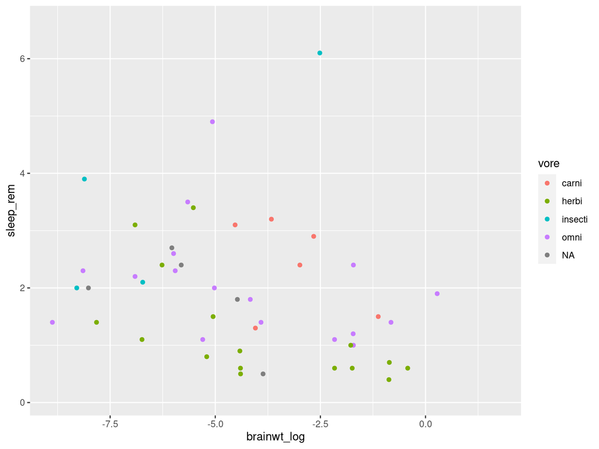

```r
ggplot(msleep2, aes(x = brainwt_log, y = sleep_rem, color = vore)) +
  geom_point()
```

This plot conveys not only the relationship between `brainwt_log` and `sleep_rem`, but each plot representing a different mammal now conveys what the feeding behavior of that mammal is.

When generating visualizations, it is important to annotate the figure with meaningful labels on the axes to make them accessible for the viewer. For that, we can use the `labs` function.

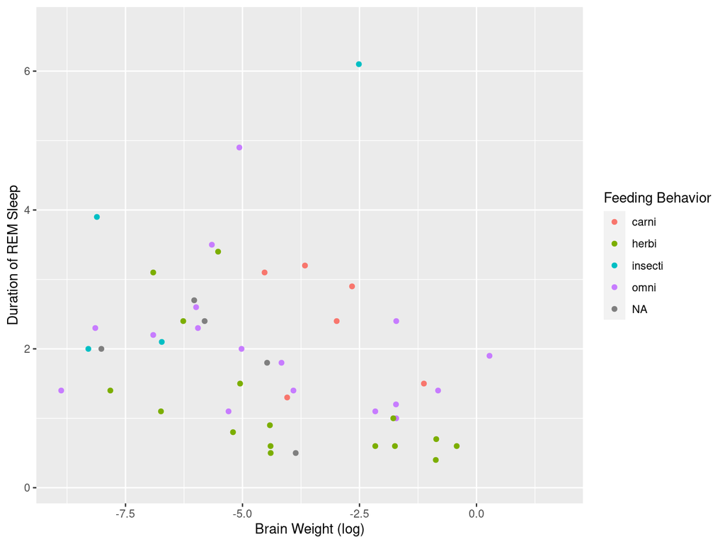

```r
ggplot(msleep2, aes(x = brainwt_log, y = sleep_rem, color = vore)) +
  geom_point() +
  labs(x = "Brain Weight (log)",
       y = "Duration of REM Sleep",
       color = "Feeding Behavior")
```

### Exploring simple plots

Let’s consider how we make other plots besides a scatterplot.

Scatterplots are a great way to look at two quantitative (numerical) values at the same time to observe patterns (i.e. correlations) between the variables or to identify interesting outliers.

However, other plots may be more useful to look at differing numbers of variables (i.e. one quantitative variable) or different types of variables (i.e. qualitative or categorical data). Here, we discuss two types of single variable plots that look at either a quantitative variable (histogram) or a categorical variable (barplot).

We can create histograms in ggplot2 that are more aesthetically pleasing than the default `hist` function. This shows the distribution of one quantitative variable.

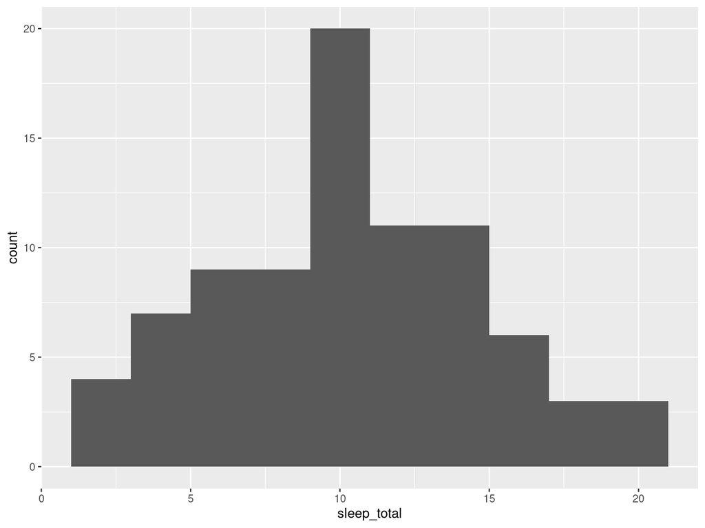

```r
ggplot(msleep, aes(x = sleep_total)) +
    geom_histogram(bins = 10)
```

We can look at how many individuals in the dataset fall into each category, such as how many mammals have each kind of feeding behavior.

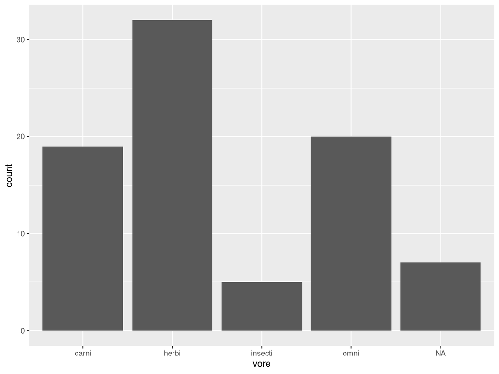

```r
ggplot(data = msleep, aes(x = vore)) +
  geom_bar()
```

As you can see where we map the aesthetic, we only tell the `ggplot` function to refer to a single column in our dataset for our x-axis.

### Visualizing between groups

Let’s return to `iris` dataset to explore how we can visualize differences between groups/categories. These groups are often represented in our data as a factor.

We can look at how the distributions of `Sepal.Length` differ depending on which species each iris belongs to. One plot that can do this easily is the `geom_boxplot` function.

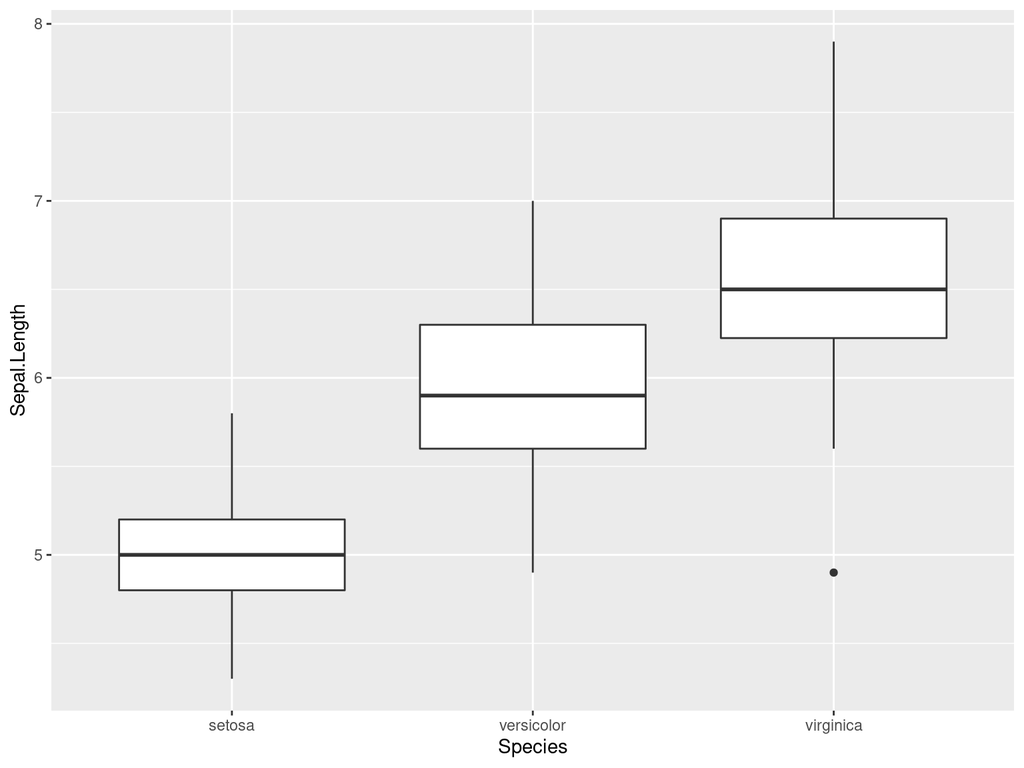

```r
ggplot(data = iris, aes(x = Species, y = Sepal.Length)) +
  geom_boxplot()
```

By adding a different parameter to `fill` in the `aes` we define throgh the `ggplot` function, we can separate out histograms according to different groupings. Here, we use `Species` to determine the color of the fill.

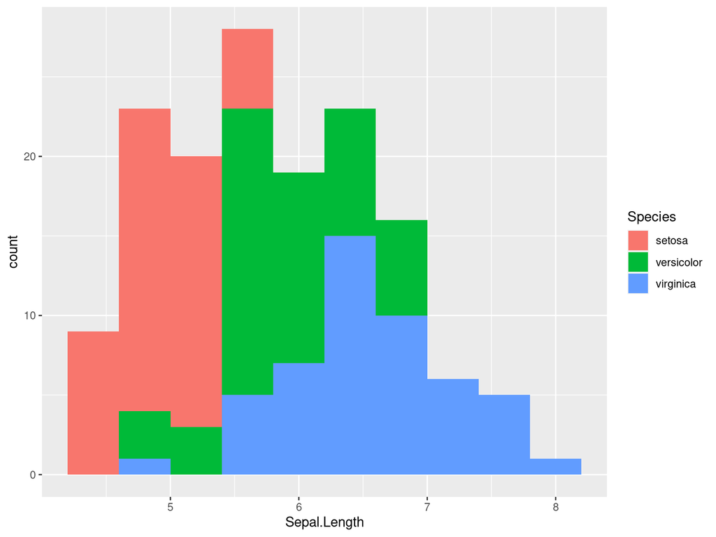

```r
ggplot(iris, aes(x = Sepal.Length, fill = Species)) +
    geom_histogram(bins = 10)
```

While we can sort of see the trends on this plot, it may be helpful to separate out each histogram for each individual species. There is an easy way to do this in `ggplot2` using facetting or the `facet_wrap` function. This function splits the figure into separate panel where the data has been filtered by the category (i.e. `Species`).

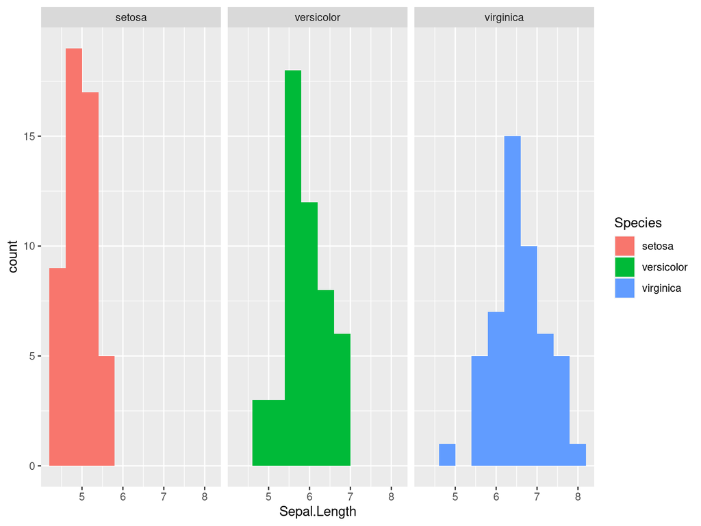

```r
ggplot(iris, aes(x = Sepal.Length, fill = Species)) +
    geom_histogram(bins = 10) +
  facet_wrap( ~ Species)
```

This matches what we already saw in the boxplot, showing that there are different sepal lengths depending on which iris species we look at. We will explore in the next section how we know if these differences are significant.

### Generating heatmaps

Heatmaps are a useful way to show the values of multiple samples across many measurements. You can visualize a heatmap by thinking of your dataframe, this tabular data, if it had each cell colorcoded based on how high or low the value is.

The base R `heatmap` function meets many needs while the ggplot2 equivalent (`geom_tile`) can be confusing so we will recommend that you not use ggplot2 for heatmaps.

Let’s go back to `msleep` dataset to visualize trends between the different measurements taken on each mammal. We will first create a simplified dataset from `msleep` where we take the log value of both `brainwt` and `bodywt`.

```r
temp.data <- cbind(log(msleep$brainwt), log(msleep$bodywt))
head(temp.data)
```

```
##            [,1]       [,2]
## [1,]         NA  3.9120230
## [2,] -4.1669153 -0.7339692
## [3,]         NA  0.3001046
## [4,] -8.1456296 -3.9633163
## [5,] -0.8603831  6.3969297
## [6,]         NA  1.3480731
```

Next, we feed these numeric values into the `heatmap` function along with some arguments that specify settings for displaying the figure. We use `labCol` to specify how to label these columns and `cexCol` to control the text size of these labels. We set `labRow` to be the names of each species from the msleep dataset.

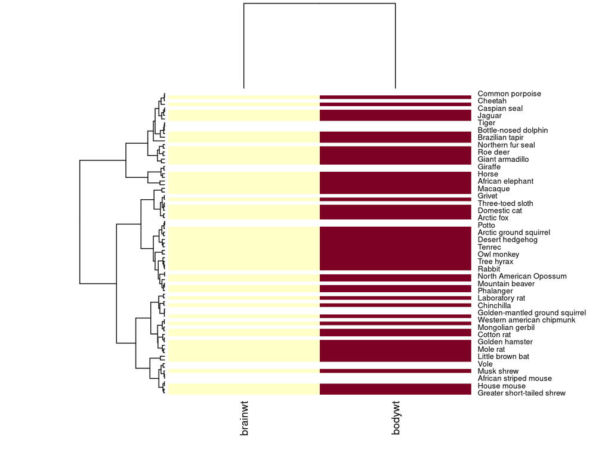

```r
heatmap(temp.data, labRow = msleep$name, labCol = c("brainwt", "bodywt"), cexCol = 1)
```

This first heatmap will look strange because it colors each box by its magnitude, but body weight of a mammal is always greater than its brain weight. We want to scale within each column so that the depth of the color reflects whether the mammal has a high brain weight or high body weight **relative to the other mammals**.

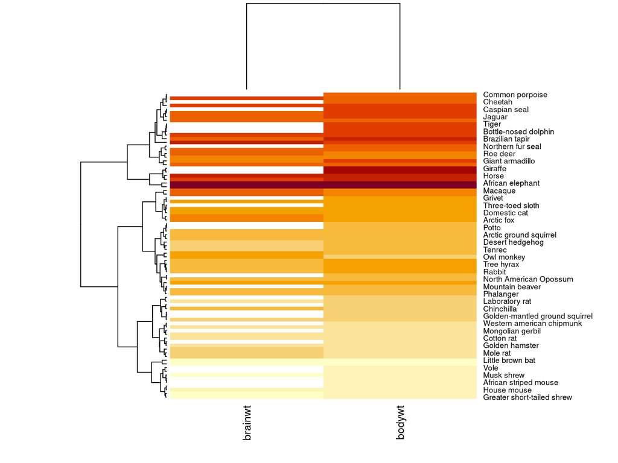

```r
heatmap(temp.data, scale = "col", labRow = msleep$name, labCol = c("brainwt", "bodywt"), cexCol = 1)
```

Let’s add some more data to our heatmap visualization.

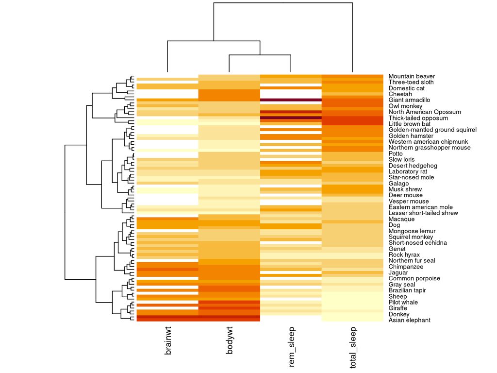

```r
temp.data2 <- cbind(temp.data, msleep$sleep_total, msleep$sleep_rem)
heatmap(temp.data2, scale = "col", labRow = msleep$name,
        labCol = c("brainwt", "bodywt", "total_sleep", "rem_sleep"), cexCol = 1)
```

You may have noticed the weird diagrams along the top and left hand side of this heatmap. These strange line diagrams are trees that show how our samples cluster together. Mammals that have similar patterns of values across these four measurements are placed near each other in the diagram.

## Making scientific figures

Making plots can be a great way to develop an intuition for your dataset, though to derive and communicate scientific insights, we need to have an idea of the uncertainty in our interpretations.

Uncertainty describes ideas such as: are the values between two groups different enough, that it is unlikely that the differences are due to chance? Is the correlation between these variables strong enough that one can predict the other, with some level of confidence? **How statistically significant are the patterns we see?**

### Plotting error bars

When we compare measurements taken from two samples (i.e. two groups), we might want to see if the two groups have very different values for that specific measurement. If we have multiple observations within each group, we can take a summary statistic such as the mean or median and plot those against each other.

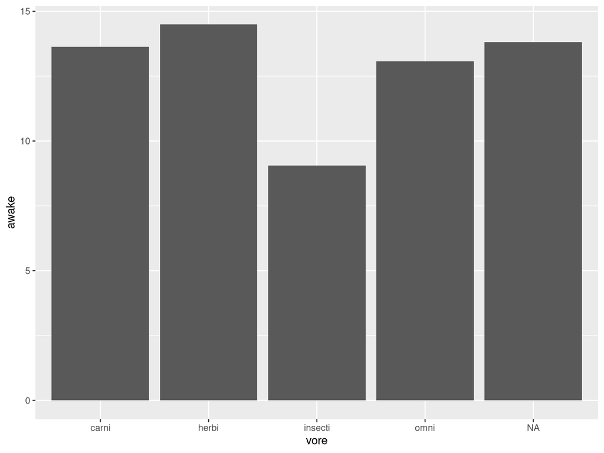

```r
ggplot(msleep2, aes(x = vore, y = awake)) +
  geom_bar(stat = "summary", fun = "mean")
```

For example, here we have asked our `geom_bar` function to plot a summary, specifically the mean of each group, instead of plotting `identity` which usually means the value as is. Looking at this figure, we can’t guess if the groups are significantly different without an idea of the uncertainty in our measurements through something like error bars.

Here is the convention for plotting error bars in ggplot2, as you can see it is just another kind of geom that we can add to our plot:

`ggplot(data = <SUMMARY DATA>, mapping = aes(<SUMMARY MAPPINGS>) + geom_bar(stat = "identity") + geom_errorbar(aes(<ERROR MAPPINGS>))`

This method is straightforward, but you need to have pre-calculated the summary statistic for each group and the amount of error (i.e. standard error) from your data. That “aggregated” dataframe becomes the data that you provide to ggplot, instead of the original dataset.

```r
feeding.data <- msleep2 %>% group_by(vore) %>%
  summarize(mean_se(awake))
feeding.data
```

```
## # A tibble: 5 x 4
##   vore        y  ymin  ymax
##   <chr>   <dbl> <dbl> <dbl>
## 1 carni   13.6  12.6   14.7
## 2 herbi   14.5  13.6   15.4
## 3 insecti  9.06  6.41  11.7
## 4 omni    13.1  12.4   13.7
## 5 <NA>    13.8  12.7   14.9
```

What does `mean_se` do? We can check.

```r
?mean_se
```

This function returns three values, `y`, `ymin`, and `ymax` which correspond to the mean, the mean minus one standard error, and the mean plus one standard error. The mean value will be the height of each bar on the barplot, while `ymin` corresponds to the bottom of the error bar and `ymax` to the top of the error bar.

Let’s first plot the height of the bars using this new `feeding.data` dataset and mapping `y` to our new `y` column generated from the `mean_se` function. Here we create the same plot as before from this aggregated dataset, just showing the mean value in each group.

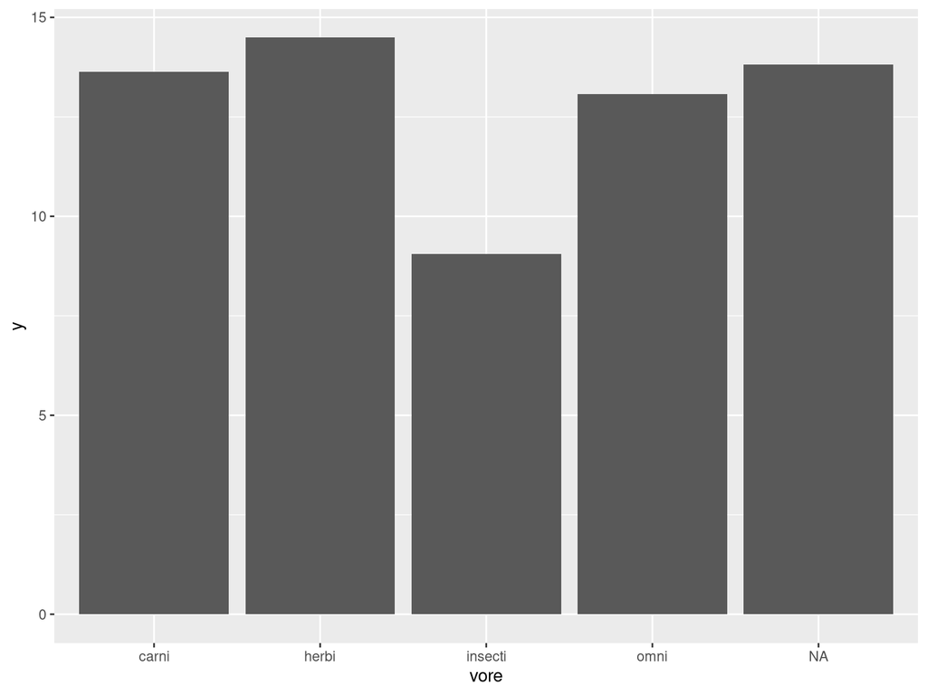

```r
my.plot <- ggplot(feeding.data, aes(x = vore, y = y)) +
  geom_bar(stat = "identity")
my.plot
```

Now we add the error bars, mapping the `ymin` and `ymax` values to the arguments that happen to have the same name in the `geom_errorbar` function. We add in the `width` setting just for aesthetics.

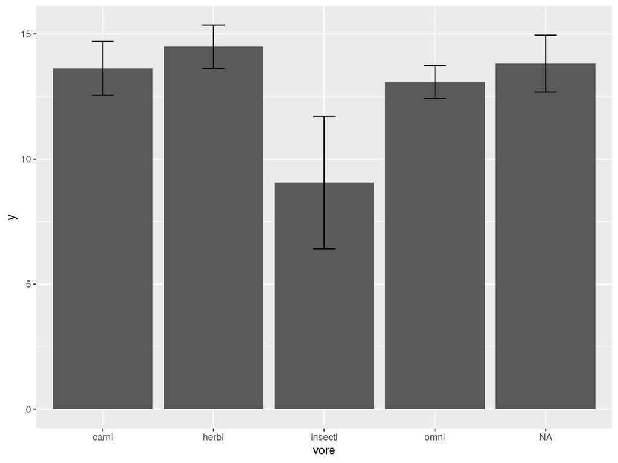

```r
my.plot <- my.plot + geom_errorbar(aes(ymin = ymin, ymax = ymax),
                                   width = 0.2)
my.plot
```

### Showing trends in data

Lots of these different figures summarize or aggregate the data. We may want to display the data with the individual points, but still show the overall trend across the data. Some good plots that do this are `geom_density_2d` which provides a contour plot.

Let’s check out the trend in our `msleep` data between body weight and brain weight. We will create a new column where we take the log value of body weight, like we did with brain weight.

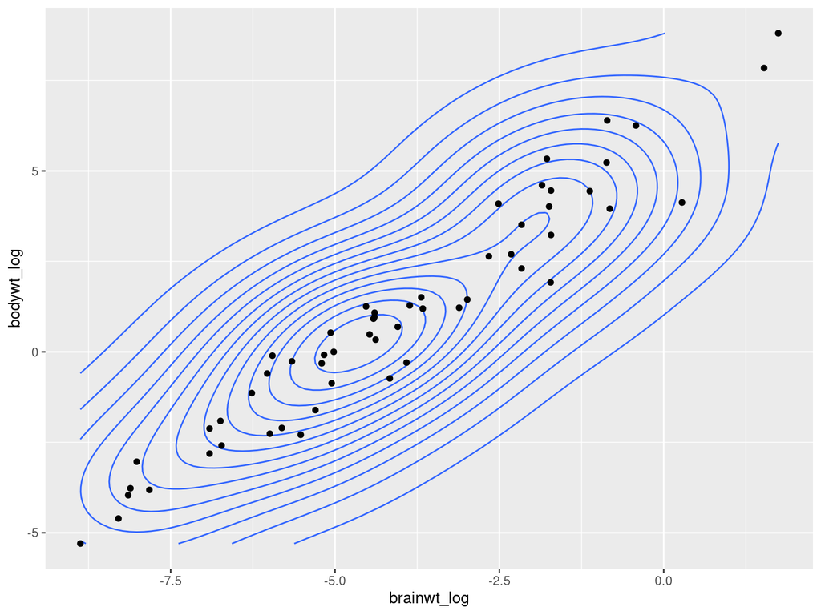

```r
msleep3 <- msleep2 %>% mutate(bodywt_log = log(bodywt))
ggplot(data = msleep3, mapping = aes(x = brainwt_log, y = bodywt_log)) +
  geom_density_2d() +
  geom_point()
```

As you can see the density of points almost look like they fit a line. As brain weight increases then body weight increases, or vice versa. We can add a trendline to this plot with the `geom_smooth` function.

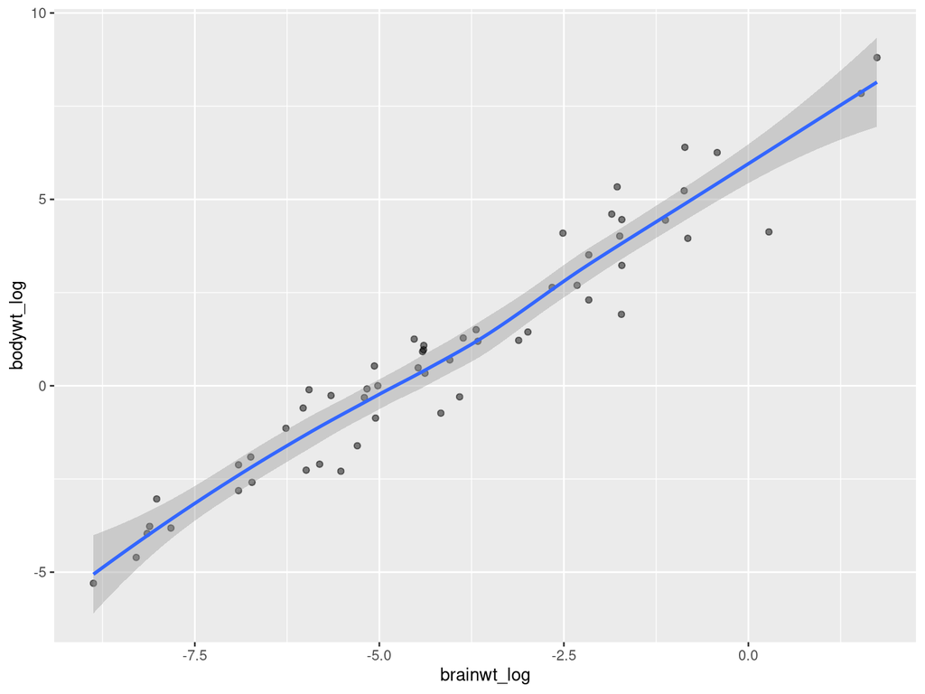

```r
ggplot(msleep3, aes(x = brainwt_log, y = bodywt_log)) +
  geom_point(alpha = 0.5) +
  geom_smooth()
```

We can also do this with trendlines that summarize only certain subsets of the data, such as those that belong to a specific category. We will flip back to our `iris` dataset to look at how sepal length compares to sepal width between different species of iris.

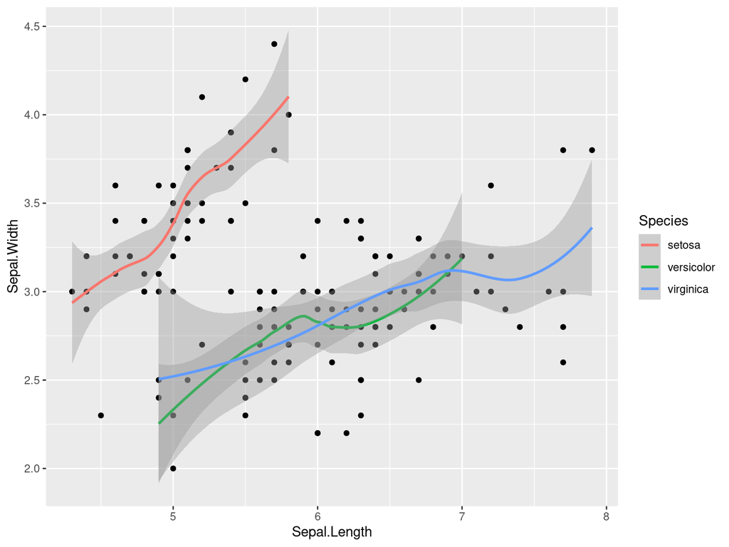

```r
ggplot(data = iris, mapping = aes(x = Sepal.Length, y = Sepal.Width)) +
  geom_point() +
  geom_smooth(aes(color = Species))
```

We create a seaprate trendline for each by specifiying the `aes` with color mapping to `Species` within the `geom_smooth` function.

The above plot may make it hard to see the data that is contributing to each trend line. Using `facet_wrap` again, we can split the figure into separate panel where the data has been filtered by the category (i.e. species).

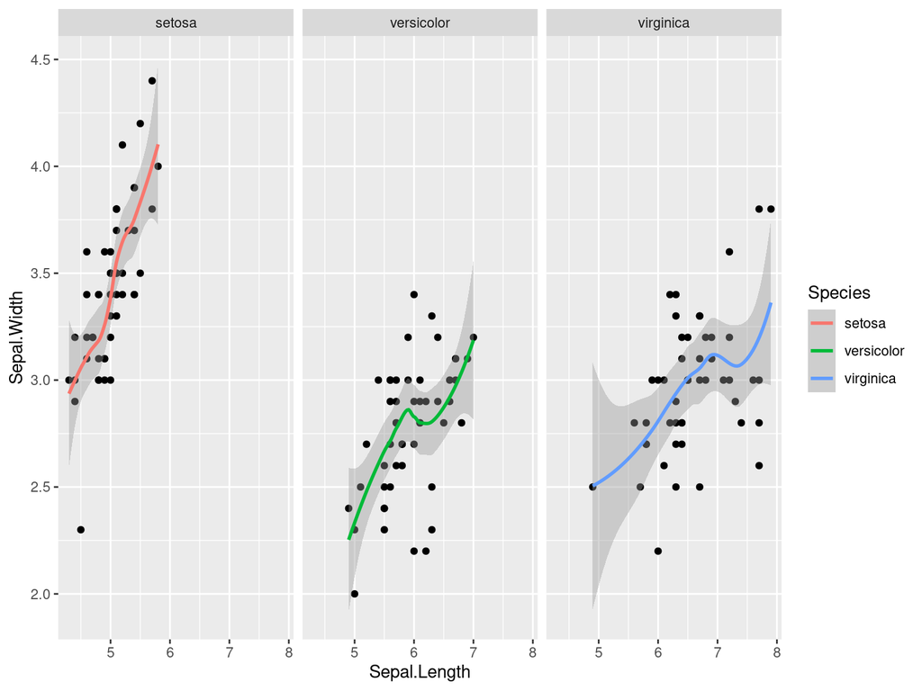

```r
ggplot(data = iris, mapping = aes(x = Sepal.Length, y = Sepal.Width)) +
  geom_point() +
  geom_smooth(aes(color = Species)) +
  facet_wrap( ~ Species)
```

Now it is clear that there is a positive correlation (as one goes up, the other goes up) in each species of iris, but some species have a sharper upward trend than others.

### Saving figures locally

As you produce analysis in your research, you may want to create high-quality images of your figures to then use in presentations or publications. There are two easy ways to save images as an individual file on your computer,

The first method uses `ggsave` to save the most recent ggplot figure you generated.

```r
ggplot(msleep2, aes(x = brainwt_log, y = sleep_rem)) + geom_point() +
  geom_smooth(method = "lm")
ggsave("plot.png", width = 5, height = 5)
```

This function will save the figure just produced by this code wherever your directory is currently. You can check your current directory with `getwd()` and change with `setwd(<FOLDER NAME>)`. You can also provide a precise file path in the new file name.

```r
ggsave("~/Downloads/plot.png", width = 5, height = 5)
```

Here is an alternative method for saving your figures:

```r
pdf("plot.pdf") # creates the file
# png() also works if you want a different file format
ggplot(msleep2, aes(x = brainwt_log, y = sleep_rem)) + geom_point() +
  geom_smooth(method = "lm")
dev.off() # finishes editing the file
```

Any changes to the figure that are contained between the initial creation of the figure (i.e. the `pdf` command) and the `dev.off` command will be included in the final saved image. However, the figure is being printed directly to the file it is writing and won’t appear elsewhere.

## Applying basic stats

Following up on our analysis using visualizations, we will review different types of statistical tests that we can perform on data. We will again revisit the mammalian sleep dataset `msleep`.

```r
head(msleep)
```

```
## # A tibble: 6 x 11
##   name  genus vore  order conservation sleep_total sleep_rem sleep_cycle awake
##   <chr> <chr> <chr> <chr> <chr>              <dbl>     <dbl>       <dbl> <dbl>
## 1 Chee… Acin… carni Carn… lc                  12.1      NA        NA      11.9
## 2 Owl … Aotus omni  Prim… <NA>                17         1.8      NA       7
## 3 Moun… Aplo… herbi Rode… nt                  14.4       2.4      NA       9.6
## 4 Grea… Blar… omni  Sori… lc                  14.9       2.3       0.133   9.1
## 5 Cow   Bos   herbi Arti… domesticated         4         0.7       0.667  20
## 6 Thre… Brad… herbi Pilo… <NA>                14.4       2.2       0.767   9.6
## # … with 2 more variables: brainwt <dbl>, bodywt <dbl>
```

### Describing quantitative variables

There are several ways to describe quantitative measurements. We might first look at the range of values using the `quantile` function, which returns the min, max, and median values as well as the 25th and 75th percentiles.

```r
quantile(msleep$brainwt, na.rm = TRUE)
```

```
##      0%     25%     50%     75%    100%
## 0.00014 0.00290 0.01240 0.12550 5.71200
```

Note that we are using the setting `na.rm = TRUE` as an argument to these functions so that it ignores `NA` values in the data.

You can also directly isolate some of these values using the functions `min` or `max`. We might describe the center of our data, that is the mean or the median values using those respective function names.

```r
median(msleep$brainwt, na.rm = TRUE)
```

```
## [1] 0.0124
```

```r
mean(msleep$brainwt, na.rm = TRUE)
```

```
## [1] 0.2815814
```

We might also want to describe the spread in the data, such as the standard deviation or the interquartile range.

```r
sd(msleep$brainwt, na.rm = TRUE)
```

```
## [1] 0.9764137
```

```r
IQR(msleep$brainwt, na.rm = TRUE)
```

```
## [1] 0.1226
```

Visualizations are a great way to see this information in one picture. We have learned to create a fancier histogram, but the `hist` function always works for quick viewing.

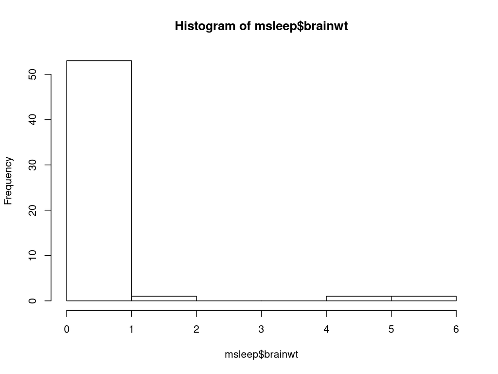

```r
hist(msleep$brainwt)
```

It is clear from this image that the data is skewed towards approaching 0 with a few high outliers.

### Finding differences in data

For the following statistical tests, we want to determine if measurements of a quantitative variable taken on a certain group of samples are different from similar measurements taken from a different group of samples.

To know if these differences are **statistically significant**, we need to be aware of the uncertainty in our data. Even if we have collect many observations, there is generally noisiness and error in those measurements. Thus, we have uncertainty if the mean value we calculate for a group is in fact the true mean.

We can calculate a confidence interval to describe our guess for the mean in our data. That is, we can identify the mean based on our samples, but also provide an upper or lower bound for where the mean might be.

```r
t.test(msleep$brainwt)
```

```
##
##  One Sample t-test
##
## data:  msleep$brainwt
## t = 2.1581, df = 55, p-value = 0.03531
## alternative hypothesis: true mean is not equal to 0
## 95 percent confidence interval:
##  0.02009613 0.54306673
## sample estimates:
## mean of x
## 0.2815814
```

We use this `t.test` function because we assume that our data is normally distributed (which is not necessarily always the case) and it has a small sample size.

calculate t-test

```r
insectivores <- msleep %>%
  filter(vore == "insecti") %>%
  select(awake)

other.mammals <- msleep %>%
  filter(vore != "insecti") %>%
  select(awake)

t.test(insectivores, other.mammals, alternative = "less")
```

```
##
##  Welch Two Sample t-test
##
## data:  insectivores and other.mammals
## t = -1.7796, df = 4.3091, p-value = 0.0723
## alternative hypothesis: true difference in means is less than 0
## 95 percent confidence interval:
##       -Inf 0.8336811
## sample estimates:
## mean of x mean of y
##   9.06000  13.86056
```

calculate ANOVA

```r
anova.msleep <- aov(awake ~ vore, data = msleep)
summary(anova.msleep)
```

```
##             Df Sum Sq Mean Sq F value Pr(>F)
## vore         3  133.7   44.58   2.234 0.0916 .
## Residuals   72 1437.0   19.96
## ---
## Signif. codes:  0 '***' 0.001 '**' 0.01 '*' 0.05 '.' 0.1 ' ' 1
## 7 observations deleted due to missingness
```

### Identifying correlations

```r
cor(msleep$brainwt, msleep$bodywt)
```

```
## [1] NA
```

know how to deal with NAs

```r
summary(msleep$brainwt)
```

```
##    Min. 1st Qu.  Median    Mean 3rd Qu.    Max.    NA's
## 0.00014 0.00290 0.01240 0.28158 0.12550 5.71200      27
```

```r
msleep2 <- msleep %>% drop_na(brainwt)
dim(msleep)
```

```
## [1] 83 11
```

```r
dim(msleep2)
```

```
## [1] 56 11
```

identify and use correlation functions use different kinds of correlation

```r
cor(msleep2$brainwt, msleep2$bodywt)
```

```
## [1] 0.9337822
```

```r
library(Hmisc)
rcorr(msleep2$brainwt, msleep2$bodywt, type = "pearson")
```

```
##      x    y
## x 1.00 0.93
## y 0.93 1.00
##
## n= 56
##
##
## P
##   x  y
## x     0
## y  0
```

```r
rcorr(msleep2$brainwt, msleep2$bodywt, type = "spearman")
```

```
##      x    y
## x 1.00 0.96
## y 0.96 1.00
##
## n= 56
##
##
## P
##   x  y
## x     0
## y  0
```

### Producing linear models

identify and use linear regression lm() using both raw variable and formulaic interfaces

```r
my.mod <- lm(formula = brainwt ~ bodywt, data = msleep2)
summary(my.mod)
```

```
##
## Call:
## lm(formula = brainwt ~ bodywt, data = msleep2)
##
## Residuals:
##      Min       1Q   Median       3Q      Max
## -0.78804 -0.08422 -0.07634 -0.02839  2.06190
##
## Coefficients:
##              Estimate Std. Error t value Pr(>|t|)
## (Intercept) 8.592e-02  4.821e-02   1.782   0.0804 .
## bodywt      9.639e-04  5.027e-05  19.176   <2e-16 ***
## ---
## Signif. codes:  0 '***' 0.001 '**' 0.01 '*' 0.05 '.' 0.1 ' ' 1
##
## Residual standard error: 0.3526 on 54 degrees of freedom
## Multiple R-squared:  0.8719, Adjusted R-squared:  0.8696
## F-statistic: 367.7 on 1 and 54 DF,  p-value: < 2.2e-16
```

```r
my.mod2 <- lm(formula = sleep_total ~ bodywt + brainwt, data = msleep2)
summary(my.mod2)
```

```
##
## Call:
## lm(formula = sleep_total ~ bodywt + brainwt, data = msleep2)
##
## Residuals:
##     Min      1Q  Median      3Q     Max
## -7.4531 -2.2517 -0.2619  2.0531  9.2283
##
## Coefficients:
##               Estimate Std. Error t value Pr(>|t|)
## (Intercept) 10.6722485  0.5898643  18.093   <2e-16 ***
## bodywt       0.0007953  0.0016703   0.476    0.636
## brainwt     -2.3518943  1.6180072  -1.454    0.152
## ---
## Signif. codes:  0 '***' 0.001 '**' 0.01 '*' 0.05 '.' 0.1 ' ' 1
##
## Residual standard error: 4.193 on 53 degrees of freedom
## Multiple R-squared:  0.1337, Adjusted R-squared:  0.101
## F-statistic: 4.088 on 2 and 53 DF,  p-value: 0.02232
```

```r
my.mod2 <- lm(formula = sleep_total ~ bodywt + brainwt, data = msleep2)
summary(my.mod2)
```

```
##
## Call:
## lm(formula = sleep_total ~ bodywt + brainwt, data = msleep2)
##
## Residuals:
##     Min      1Q  Median      3Q     Max
## -7.4531 -2.2517 -0.2619  2.0531  9.2283
##
## Coefficients:
##               Estimate Std. Error t value Pr(>|t|)
## (Intercept) 10.6722485  0.5898643  18.093   <2e-16 ***
## bodywt       0.0007953  0.0016703   0.476    0.636
## brainwt     -2.3518943  1.6180072  -1.454    0.152
## ---
## Signif. codes:  0 '***' 0.001 '**' 0.01 '*' 0.05 '.' 0.1 ' ' 1
##
## Residual standard error: 4.193 on 53 degrees of freedom
## Multiple R-squared:  0.1337, Adjusted R-squared:  0.101
## F-statistic: 4.088 on 2 and 53 DF,  p-value: 0.02232
```